# Convolutional Neural Networks

## Algorithm for a Dog Identification

### Task

If a dog is detected in the image, it will provide an estimate of the dog's breed. If a human is detected, it will provide an estimate of the dog breed that is most resembling.

### The Road Ahead

We break the notebook into separate steps.

- Step 0: Import Datasets
- Step 1: Detect Humans
- Step 2: Detect Dogs
- Step 3: Create a CNN to Classify Dog Breeds (from Scratch)
- Step 4: Create a CNN to Classify Dog Breeds (using Transfer Learning)
- Step 5: Write Algorithm
- Step 6: Test Algorithm

## Step 0: Import Datasets

```python
import numpy as np
from glob import glob

# load filenames for human and dog images
human_files = np.array(glob("/data/lfw/*/*"))
dog_files = np.array(glob("/data/dog_images/*/*/*"))

# print number of images in each dataset
print(f'There are {len(human_files)} total human images.')
print(f'There are {len(dog_files)} total dog images.')
```

```
There are 13233 total human images.
There are 8351 total dog images.
```

## Step 1: Detect Humans

In this section, we use OpenCV's implementation of [Haar feature-based cascade classifiers](http://docs.opencv.org/trunk/d7/d8b/tutorial_py_face_detection.html) to detect human faces in images.

```
Number of faces detected: 1
```

```python
import cv2
import matplotlib.pyplot as plt
%matplotlib inline

# extract pre-trained face detector
face_cascade = cv2.CascadeClassifier('haarcascades/haarcascade_frontalface_alt.xml')

# load color (BGR) image
img = cv2.imread(human_files[0])
# convert BGR image to grayscale
gray = cv2.cvtColor(img, cv2.COLOR_BGR2GRAY)

# find faces in image
faces = face_cascade.detectMultiScale(gray)

# print number of faces detected in the image
print('Number of faces detected:', len(faces))

# get bounding box for each detected face
for (x,y,w,h) in faces:
    # add bounding box to color image
    cv2.rectangle(img,(x,y),(x+w,y+h),(255,0,0),2)

# convert BGR image to RGB for plotting
cv_rgb = cv2.cvtColor(img, cv2.COLOR_BGR2RGB)

# display the image, along with bounding box
plt.imshow(cv_rgb)
plt.show()
```

[output not shown]

Before using any of the face detectors, it is standard procedure to convert the images to grayscale. The `detectMultiScale` function executes the classifier stored in `face_cascade` and takes the grayscale image as a parameter.

In the above code, `faces` is a numpy array of detected faces, where each row corresponds to a detected face. Each detected face is a 1D array with four entries that specifies the bounding box of the detected face. The first two entries in the array (extracted in the above code as `x` and `y`) specify the horizontal and vertical positions of the top left corner of the bounding box. The last two entries in the array (extracted here as `w` and `h`) specify the width and height of the box.

### Write a Human Face Detector

We can use this procedure to write a function that returns `True` if a human face is detected in an image and `False` otherwise. This function, aptly named `face_detector`, takes a string-valued file path to an image as input and appears in the code block below.

```python
# returns "True" if face is detected in image stored at img_path
def face_detector(img_path):
    img = cv2.imread(img_path)
    gray = cv2.cvtColor(img, cv2.COLOR_BGR2GRAY)
    human_faces = face_cascade.detectMultiScale(gray)
    return len(human_faces) > 0
```

## Step 2: Detect Dogs

In this section, we use a [pre-trained model](http://pytorch.org/docs/master/torchvision/models.html) to detect dogs in images.

### Obtain Pre-trained VGG-16 Model

The code cell below downloads the VGG-16 model, along with weights that have been trained on [ImageNet](http://www.image-net.org/), a very large, very popular dataset used for image classification and other vision tasks. ImageNet contains over 10 million URLs, each linking to an image containing an object from one of [1000 categories](https://gist.github.com/yrevar/942d3a0ac09ec9e5eb3a).

```python
import torch
import torchvision.models as models

# define VGG16 model
VGG16 = models.vgg16(pretrained=True)

# check if CUDA is available
use_cuda = torch.cuda.is_available()

# move model to GPU if CUDA is available
if use_cuda:
    VGG16 = VGG16.cuda()
```

Given an image, this pre-trained VGG-16 model returns a prediction (derived from the 1000 possible categories in ImageNet) for the object that is contained in the image.

### Making Predictions with a Pre-trained Model

In the next code cell, we will write a function that accepts a path to an image (such as `'dogImages/train/001.Affenpinscher/Affenpinscher_00001.jpg'`) as input and returns the index corresponding to the ImageNet class that is predicted by the pre-trained VGG-16 model. The output should always be an integer between 0 and 999, inclusive.

```python
from PIL import Image
import torchvision.transforms as transforms
import torchvision
from torchvision import datasets, models, transforms
def VGG16_predict(img_path):
    '''
    Use pre-trained VGG-16 model to obtain index corresponding to
    predicted ImageNet class for image at specified path

    Args:
        img_path: path to an image

    Returns:
        Index corresponding to VGG-16 model's prediction
    '''

    ## Load and pre-process an image from the given img_path


    image = Image.open(img_path)

    data_transform = transforms.Compose([transforms.RandomResizedCrop(224),
                                          transforms.ToTensor()])

    image_tensor = data_transform(image)
    image_tensor = image_tensor.unsqueeze(0)

    # move tensor to cuda
    if torch.cuda.is_available():
        image_tensor = image_tensor.cuda()



    ## Return the *index* of the predicted class for that image
    output = VGG16(image_tensor)

    if torch.cuda.is_available():
        output = output.cpu()

    class_index = output.data.numpy().argmax()

    return class_index # predicted class index
```

[output not shown]

### Write a Dog Detector

While looking at the [dictionary](https://gist.github.com/yrevar/942d3a0ac09ec9e5eb3a), we notice that the categories corresponding to dogs appear in an uninterrupted sequence and correspond to dictionary keys 151-268, inclusive, to include all categories from `'Chihuahua'` to `'Mexican hairless'`. Thus, in order to check to see if an image is predicted to contain a dog by the pre-trained VGG-16 model, we need only check if the pre-trained model predicts an index between 151 and 268 (inclusive).

```python
### returns "True" if a dog is detected in the image stored at img_path
def dog_detector(img_path):
    class_index = VGG16_predict(img_path)
    return (151 <= class_index <= 268)
```

### Assess the Dog Detector

- What percentage of the images in `human_files_short` have a detected dog?
- What percentage of the images in `dog_files_short` have a detected dog?

**Answer:** 0 percentage of the images in human_files_short have a detected dog

74 percentage of the images in dog_files_short have a detected dog

```python
### Test the performance of the dog_detector function
### on the images in human_files_short and dog_files_short.
list_human = [dog_detector(human_files_short[i]) for i in range (0, 100)]
print (sum (list_human))

list_dog = [dog_detector(dog_files_short[i]) for i in range (0, 100)]
print (sum (list_dog))
```

```
0
74
```

## Step 3: Create a CNN to Classify Dog Breeds (from Scratch)

Now that we have functions for detecting humans and dogs in images, we need a way to predict breed from images. In this step, we will create a CNN that classifies dog breeds.

### Specify Data Loaders for the Dog Dataset

```python
import os
import torch
from torchvision import datasets
from PIL import ImageFile
ImageFile.LOAD_TRUNCATED_IMAGES = True
import torchvision.transforms as transforms

### Write data loaders for training, validation, and test sets
## Specify appropriate transforms, and batch_sizes

# define dataloader parameters
batch_size = 20
num_workers=0

# define training and test data directories
data_dir = '/data/dog_images/'
train_dir = os.path.join(data_dir, 'train/')
test_dir = os.path.join(data_dir, 'test/')
validation_dir = os.path.join(data_dir, 'valid/')


data_transform = transforms.Compose([transforms.RandomResizedCrop(224),
transforms.RandomHorizontalFlip(), # randomly flip and rotate
transforms.RandomRotation(10),
transforms.ToTensor(),
transforms.Normalize((0.5, 0.5, 0.5), (0.5, 0.5, 0.5))
])

# prepare data loaders
train_data = datasets.ImageFolder(train_dir, transform=data_transform)
validation_data = datasets.ImageFolder(validation_dir, transform=data_transform)
test_data = datasets.ImageFolder(test_dir, transform=data_transform)

train_loader = torch.utils.data.DataLoader(train_data, batch_size=batch_size,
                                           num_workers=num_workers, shuffle=True)
valid_loader = torch.utils.data.DataLoader(validation_data, batch_size=batch_size,
                                           num_workers=num_workers, shuffle=True)
test_loader = torch.utils.data.DataLoader(test_data, batch_size=batch_size,
                                          num_workers=num_workers, shuffle=True)

loaders_scratch = {
    'train': train_loader,
    'valid': valid_loader,
    'test': test_loader
}
```

```python
import matplotlib.pyplot as plt
%matplotlib inline
import numpy as np
# helper function to un-normalize and display an image
def imshow(img):
    img = img / 2 + 0.5  # unnormalize
    plt.imshow(np.transpose(img, (1, 2, 0)))  # convert from Tensor image
```

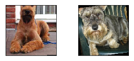

```python
# obtain one batch of training images
dataiter = iter(train_loader)
images, labels = dataiter.next()
images = images.numpy() # convert images to numpy for display

# plot the images in the batch, along with the corresponding labels
fig = plt.figure(figsize=(25, 4))
# display 20 images
for idx in np.arange(2):
    ax = fig.add_subplot(2, 20/2, idx+1, xticks=[], yticks=[])
    imshow(images[idx])
```

Images are resized using RandomResizedCrop. Size 224 was pciked for input tensor by looking at the published articles online. That seemed the most appropriate size to take. The dataset was augmented by the techniques mentioned in the videos using RandomHorizontalFlip, RandomRotation.Image file was finally converted to tensor and normalized.

### Model Architecture

Create a CNN to classify dog breed. Use the template in the code cell below.

```python
import torch.nn as nn
import torch.nn.functional as F

# define the CNN architecture
class Net(nn.Module):
    ### choose an architecture, and complete the class
    def __init__(self):
        super(Net, self).__init__()
        ## Define layers of a CNN
        # convolutional layer (sees 224x224x3 image tensor)
        self.conv1 = nn.Conv2d(3, 32, 3, padding=1)
        # convolutional layer (sees 112x112x16 tensor)
        self.conv2 = nn.Conv2d(32, 64, 3, padding=1)
        # convolutional layer (sees 64x64x32 tensor)
        self.conv3 = nn.Conv2d(64, 128, 3, padding=1)
        # max pooling layer
        self.pool = nn.MaxPool2d(2, 2)
        # linear layer (128 * 28 * 28 -> 500)
        self.fc1 = nn.Linear(128 * 28 * 28, 500)
        # linear layer (500 -> 133)
        self.fc2 = nn.Linear(500, 133)
        # dropout layer (p=0.25)
        self.dropout = nn.Dropout(0.25)
    def forward(self, x):
        ## Define forward behavior
        x = self.pool(F.relu(self.conv1(x)))
        x = self.pool(F.relu(self.conv2(x)))
        x = self.pool(F.relu(self.conv3(x)))
        # flatten image input
        x = x.view(-1, 128 * 28 * 28)
        # add dropout layer
        x = self.dropout(x)
        # add 1st hidden layer, with relu activation function
        x = F.relu(self.fc1(x))
        # add dropout layer
        x = self.dropout(x)
        # add 2nd hidden layer, with relu activation function
        x = self.fc2(x)
        return x

# instantiate the CNN
model_scratch = Net()

# move tensors to GPU if CUDA is available
if use_cuda:
    model_scratch.cuda()
```

### Specify Loss Function and Optimizer

```python
import torch.optim as optim

### select loss function
criterion_scratch = nn.CrossEntropyLoss()

### select optimizer
optimizer_scratch = optim.SGD(model_scratch.parameters(), lr=0.01)

if use_cuda:
    criterion_scratch = criterion_scratch.cuda()
```

### Train and Validate the Model

```python
def train(n_epochs, loaders, model, optimizer, criterion, use_cuda, save_path):
    """returns trained model"""
    # initialize tracker for minimum validation loss
    valid_loss_min = np.Inf

    for epoch in range(1, n_epochs+1):
        # initialize loss variables for training loss and validation loss
        train_loss = 0.0
        valid_loss = 0.0

        # train the model

        model.train()
        for batch_idx, (data, target) in enumerate(loaders['train']):
            # move to GPU
            if use_cuda:
                data, target = data.cuda(), target.cuda()
            ## update the model parameters
                optimizer.zero_grad()
                output = model(data)
                loss = criterion(output, target)
                loss.backward()
                optimizer.step()


            ## average training loss
                train_loss = train_loss + ((1 / (batch_idx + 1)) * (loss.data - train_loss))

        # validate the model
        model.eval()
        for batch_idx, (data, target) in enumerate(loaders['valid']):
            # move to GPU
            if use_cuda:
                data, target = data.cuda(), target.cuda()
            output = model(data)
            # calculate loss and update average validation loss
            loss = criterion(output, target)
            valid_loss = valid_loss + ((1 / (batch_idx + 1)) * (loss.data - valid_loss))

        # training/validation loss
        print('Epoch: {} \tTraining Loss: {:.6f} \tValidation Loss: {:.6f}'.format(
            epoch,
            train_loss,
            valid_loss
            ))

        ## save the model if validation loss has decreased
        if valid_loss <= valid_loss_min:
            print(f'Validation loss decreased ({valid_loss_min} --> {valid_loss}).  Saving model ...')
            torch.save(model.state_dict(), save_path)
            valid_loss_min = valid_loss
    # return trained model
    return model


# train the model
model_scratch = train(50, loaders_scratch, model_scratch, optimizer_scratch, criterion_scratch, use_cuda, 'model_scratch.pt')

# load the model with best validation accuracy
model_scratch.load_state_dict(torch.load('model_scratch.pt'))
```

```
Epoch: 1 	Training Loss: 4.883908 	Validation Loss: 4.867745
Validation loss decreased (inf --> 4.8677449226379395).  Saving model ...
Epoch: 2 	Training Loss: 4.857948 	Validation Loss: 4.828182
Validation loss decreased (4.8677449226379395 --> 4.828181743621826).  Saving model ...
Epoch: 3 	Training Loss: 4.776867 	Validation Loss: 4.714515
Validation loss decreased (4.828181743621826 --> 4.714515209197998).  Saving model ...
Epoch: 4 	Training Loss: 4.653889 	Validation Loss: 4.627423
Validation loss decreased (4.714515209197998 --> 4.62742280960083).  Saving model ...
Epoch: 5 	Training Loss: 4.603976 	Validation Loss: 4.595919
Validation loss decreased (4.62742280960083 --> 4.595919132232666).  Saving model ...
Epoch: 6 	Training Loss: 4.562114 	Validation Loss: 4.592135
Validation loss decreased (4.595919132232666 --> 4.592134952545166).  Saving model ...
Epoch: 7 	Training Loss: 4.527866 	Validation Loss: 4.517825
Validation loss decreased (4.592134952545166 --> 4.517824649810791).  Saving model ...
Epoch: 8 	Training Loss: 4.497367 	Validation Loss: 4.512098
Validation loss decreased (4.517824649810791 --> 4.51209831237793).  Saving model ...
Epoch: 9 	Training Loss: 4.473951 	Validation Loss: 4.484348
Validation loss decreased (4.51209831237793 --> 4.484348297119141).  Saving model ...
Epoch: 10 	Training Loss: 4.437525 	Validation Loss: 4.456133
Validation loss decreased (4.484348297119141 --> 4.456132888793945).  Saving model ...
Epoch: 11 	Training Loss: 4.391824 	Validation Loss: 4.421599
Validation loss decreased (4.456132888793945 --> 4.4215989112854).  Saving model ...
Epoch: 12 	Training Loss: 4.370867 	Validation Loss: 4.465789
Epoch: 13 	Training Loss: 4.345278 	Validation Loss: 4.371666
Validation loss decreased (4.4215989112854 --> 4.371665954589844).  Saving model ...
Epoch: 14 	Training Loss: 4.327038 	Validation Loss: 4.431526
Epoch: 15 	Training Loss: 4.314827 	Validation Loss: 4.408340
Epoch: 16 	Training Loss: 4.274291 	Validation Loss: 4.339738
Validation loss decreased (4.371665954589844 --> 4.339737892150879).  Saving model ...
Epoch: 17 	Training Loss: 4.255634 	Validation Loss: 4.365775
Epoch: 18 	Training Loss: 4.236125 	Validation Loss: 4.359012
Epoch: 19 	Training Loss: 4.199792 	Validation Loss: 4.341966
Epoch: 20 	Training Loss: 4.168004 	Validation Loss: 4.377005
Epoch: 21 	Training Loss: 4.148744 	Validation Loss: 4.310865
Validation loss decreased (4.339737892150879 --> 4.3108649253845215).  Saving model ...
Epoch: 22 	Training Loss: 4.126297 	Validation Loss: 4.322583
Epoch: 23 	Training Loss: 4.105670 	Validation Loss: 4.290994
Validation loss decreased (4.3108649253845215 --> 4.290994167327881).  Saving model ...
Epoch: 24 	Training Loss: 4.078447 	Validation Loss: 4.200477
Validation loss decreased (4.290994167327881 --> 4.200477123260498).  Saving model ...
```

[output cut: 23 more lines]

```
Epoch: 40 	Training Loss: 3.678439 	Validation Loss: 4.066415
Epoch: 41 	Training Loss: 3.663081 	Validation Loss: 4.055721
Epoch: 42 	Training Loss: 3.651802 	Validation Loss: 4.059011
Epoch: 43 	Training Loss: 3.607549 	Validation Loss: 4.217405
Epoch: 44 	Training Loss: 3.590004 	Validation Loss: 4.035468
Validation loss decreased (4.053328037261963 --> 4.035468101501465).  Saving model ...
Epoch: 45 	Training Loss: 3.592422 	Validation Loss: 4.007452
Validation loss decreased (4.035468101501465 --> 4.00745153427124).  Saving model ...
Epoch: 46 	Training Loss: 3.565088 	Validation Loss: 4.053574
Epoch: 47 	Training Loss: 3.537142 	Validation Loss: 4.098477
Epoch: 48 	Training Loss: 3.493073 	Validation Loss: 4.099118
Epoch: 49 	Training Loss: 3.471225 	Validation Loss: 4.001259
Validation loss decreased (4.00745153427124 --> 4.0012593269348145).  Saving model ...
Epoch: 50 	Training Loss: 3.496581 	Validation Loss: 3.980536
Validation loss decreased (4.0012593269348145 --> 3.9805357456207275).  Saving model ...
```

### Test the Model

```python
def test(loaders, model, criterion, use_cuda):

    # monitor test loss and accuracy
    test_loss = 0.
    correct = 0.
    total = 0.

    model.eval()
    for batch_idx, (data, target) in enumerate(loaders['test']):
        # move to GPU
        if use_cuda:
            data, target = data.cuda(), target.cuda()
        # forward pass: compute predicted outputs by passing inputs to the model
        output = model(data)
        # calculate the loss
        loss = criterion(output, target)
        # update average test loss
        test_loss = test_loss + ((1 / (batch_idx + 1)) * (loss.data - test_loss))
        # convert output probabilities to predicted class
        pred = output.data.max(1, keepdim=True)[1]
        # compare predictions to true label
        correct += np.sum(np.squeeze(pred.eq(target.data.view_as(pred))).cpu().numpy())
        total += data.size(0)

    print(f'Test Loss: {test_loss}')

    print('\nTest Accuracy: %2d%% (%2d/%2d)' % (
        100. * correct / total, correct, total))

# call test function
test(loaders_scratch, model_scratch, criterion_scratch, use_cuda)
```

```
Test Loss: 3.9477438926696777

Test Accuracy: 11% (97/836)
```

## Step 4: Create a CNN to Classify Dog Breeds (using Transfer Learning)

### Specify Data Loaders for the Dog Dataset

```python
#Specify data loaders
loaders_transfer = loaders_scratch.copy()
```

### Model Architecture

```python
import torchvision.models as models
import torch.nn as nn

## Specify model architecture
model_transfer = models.resnet50(pretrained=True)

for param in model_transfer.parameters():
    param.requires_grad = False

model_transfer.fc = nn.Linear(2048, 133, bias=True)

model_fc_parameters = model_transfer.fc.parameters()

for param in model_fc_parameters:
    param.requires_grad = True

if use_cuda:
    model_transfer = model_transfer.cuda()
```

```
Downloading: "https://download.pytorch.org/models/resnet50-19c8e357.pth" to /root/.torch/models/resnet50-19c8e357.pth
```

ResNet is chosen as this model was the winner of ImageNet challenge in 2015. It is a good starting point for transfer learning. Final fully connected layer ouput is 133 as thats the total classes of dog we have.

### Specify Loss Function and Optimizer

```python
criterion_transfer = nn.CrossEntropyLoss()
optimizer_transfer = optim.SGD(model_transfer.fc.parameters(), lr=0.001)
```

### Train and Validate the Model

```python
def train(n_epochs, loaders, model, optimizer, criterion, use_cuda, save_path):
    """returns trained model"""

    # initialize tracker for minimum validation loss
    valid_loss_min = np.Inf

    for epoch in range(1, n_epochs+1):
        # initialize loss variables for training and validation loss
        train_loss = 0.0
        valid_loss = 0.0

        # train the model
        model.train()
        for batch_idx, (data, target) in enumerate(loaders['train']):
            # move to GPU
            if use_cuda:
                data, target = data.cuda(), target.cuda()

            optimizer.zero_grad()
            # forward pass: compute predicted outputs by passing inputs to the model
            output = model(data)
            # calculate the batch loss
            loss = criterion(output, target)
            # backward pass: compute gradient of the loss with respect to model parameters
            loss.backward()
            # perform a single optimization step (parameter update)
            optimizer.step()

            train_loss = train_loss + ((1 / (batch_idx + 1)) * (loss.data - train_loss))


        # validate the model
        model.eval()
        for batch_idx, (data, target) in enumerate(loaders['valid']):
            # move to GPU
            if use_cuda:
                data, target = data.cuda(), target.cuda()
            ## update the average validation loss
            output = model(data)
            loss = criterion(output, target)
            valid_loss = valid_loss + ((1 / (batch_idx + 1)) * (loss.data - valid_loss))

        # print training/validation loss
        print('Epoch: {} \tTraining Loss: {:.6f} \tValidation Loss: {:.6f}'.format(
            epoch,
            train_loss,
            valid_loss
            ))

        ## save the model if validation loss has decreased
        if valid_loss < valid_loss_min:
            torch.save(model.state_dict(), save_path)
            print('Validation loss decreased ({:.6f} --> {:.6f}).  Saving model ...'
                  .format(valid_loss_min, valid_loss))
            valid_loss_min = valid_loss

    # return trained model
    return model

n_epochs = 50

# train the model
model_transfer = train(n_epochs, loaders_transfer, model_transfer, optimizer_transfer, criterion_transfer,
                       use_cuda, 'model_transfer.pt')

# load the model that got the best validation accuracy
model_transfer.load_state_dict(torch.load('model_transfer.pt'))
```

```
Epoch: 1 	Training Loss: 4.825168 	Validation Loss: 4.703339
Validation loss decreased (inf --> 4.703339).  Saving model ...
Epoch: 2 	Training Loss: 4.629292 	Validation Loss: 4.499588
Validation loss decreased (4.703339 --> 4.499588).  Saving model ...
Epoch: 3 	Training Loss: 4.458992 	Validation Loss: 4.306858
Validation loss decreased (4.499588 --> 4.306858).  Saving model ...
Epoch: 4 	Training Loss: 4.290055 	Validation Loss: 4.156352
Validation loss decreased (4.306858 --> 4.156352).  Saving model ...
Epoch: 5 	Training Loss: 4.129441 	Validation Loss: 3.987661
Validation loss decreased (4.156352 --> 3.987661).  Saving model ...
Epoch: 6 	Training Loss: 3.979967 	Validation Loss: 3.838576
Validation loss decreased (3.987661 --> 3.838576).  Saving model ...
Epoch: 7 	Training Loss: 3.828594 	Validation Loss: 3.672453
Validation loss decreased (3.838576 --> 3.672453).  Saving model ...
Epoch: 8 	Training Loss: 3.711260 	Validation Loss: 3.463255
Validation loss decreased (3.672453 --> 3.463255).  Saving model ...
Epoch: 9 	Training Loss: 3.566027 	Validation Loss: 3.395427
Validation loss decreased (3.463255 --> 3.395427).  Saving model ...
Epoch: 10 	Training Loss: 3.437756 	Validation Loss: 3.253336
Validation loss decreased (3.395427 --> 3.253336).  Saving model ...
Epoch: 11 	Training Loss: 3.337365 	Validation Loss: 3.119250
Validation loss decreased (3.253336 --> 3.119250).  Saving model ...
Epoch: 12 	Training Loss: 3.217595 	Validation Loss: 3.015644
Validation loss decreased (3.119250 --> 3.015644).  Saving model ...
Epoch: 13 	Training Loss: 3.130946 	Validation Loss: 2.875268
Validation loss decreased (3.015644 --> 2.875268).  Saving model ...
Epoch: 14 	Training Loss: 3.003729 	Validation Loss: 2.834037
Validation loss decreased (2.875268 --> 2.834037).  Saving model ...
Epoch: 15 	Training Loss: 2.914529 	Validation Loss: 2.729851
Validation loss decreased (2.834037 --> 2.729851).  Saving model ...
Epoch: 16 	Training Loss: 2.849252 	Validation Loss: 2.645480
Validation loss decreased (2.729851 --> 2.645480).  Saving model ...
Epoch: 17 	Training Loss: 2.767242 	Validation Loss: 2.594935
Validation loss decreased (2.645480 --> 2.594935).  Saving model ...
Epoch: 18 	Training Loss: 2.692084 	Validation Loss: 2.504748
Validation loss decreased (2.594935 --> 2.504748).  Saving model ...
Epoch: 19 	Training Loss: 2.613697 	Validation Loss: 2.431084
Validation loss decreased (2.504748 --> 2.431084).  Saving model ...
Epoch: 20 	Training Loss: 2.542523 	Validation Loss: 2.380444
Validation loss decreased (2.431084 --> 2.380444).  Saving model ...
```

[output cut: 32 more lines]

```
Epoch: 41 	Training Loss: 1.762377 	Validation Loss: 1.602790
Epoch: 42 	Training Loss: 1.726585 	Validation Loss: 1.523098
Validation loss decreased (1.596139 --> 1.523098).  Saving model ...
Epoch: 43 	Training Loss: 1.713249 	Validation Loss: 1.517028
Validation loss decreased (1.523098 --> 1.517028).  Saving model ...
Epoch: 44 	Training Loss: 1.726695 	Validation Loss: 1.531536
Epoch: 45 	Training Loss: 1.684299 	Validation Loss: 1.506107
Validation loss decreased (1.517028 --> 1.506107).  Saving model ...
Epoch: 46 	Training Loss: 1.645051 	Validation Loss: 1.518529
Epoch: 47 	Training Loss: 1.653809 	Validation Loss: 1.527501
Epoch: 48 	Training Loss: 1.630452 	Validation Loss: 1.549457
Epoch: 49 	Training Loss: 1.603473 	Validation Loss: 1.483806
Validation loss decreased (1.506107 --> 1.483806).  Saving model ...
Epoch: 50 	Training Loss: 1.599444 	Validation Loss: 1.427736
Validation loss decreased (1.483806 --> 1.427736).  Saving model ...
```

### Test the Model

```python
test(loaders_transfer, model_transfer, criterion_transfer, use_cuda)
```

```
Test Loss: 1.4854999780654907

Test Accuracy: 69% (583/836)
```

### Predict Dog Breed with the Model

```python
from PIL import Image
import torchvision.transforms as transforms

data_transfer = loaders_transfer.copy()

# list of class names by index, i.e. a name can be accessed like class_names[0]
class_names = [item[4:].replace("_", " ") for item in data_transfer['train'].dataset.classes]

def predict_breed_transfer(img_path):
    ### a function that takes a path to an image as input
    ### and returns the dog breed that is predicted by the model.

    global model_transfer
    global data_transform

    # load the image and return the predicted breed
    image = Image.open(img_path).convert('RGB')

    # Removing transparent, alpha
    image = data_transform(image)[:3,:,:].unsqueeze(0)

    if use_cuda:
        model_transfer = model_transfer.cuda()
        image = image.cuda()

    model_transfer.eval()
    idx = torch.argmax(model_transfer(image))
    return class_names[idx]
```

[output not shown]

## Step 5: Write Algorithm

- if a **dog** is detected in the image, return the predicted breed.
- if a **human** is detected in the image, return the resembling dog breed.
- if **neither** is detected in the image, provide output that indicates an error.

```python
def run_app(img_path):
    ## handle cases for a human face, dog, and neither
    if face_detector(img_path) > 0:
        breed = predict_breed_transfer(img_path)
        print('Human / resembling dog breed is ' + breed)
    elif dog_detector(img_path):
        breed = predict_breed_transfer(img_path)
        print('Dog / predicted dog breed is ' + breed)
    else:
        print('Not Human, Neither Dog')
```

## Step 6: Test Algorithm

1. More datapoints for each dog class would improve accuracy.
2. Better transfer learning models may be more layers
3. More epochs is increasing score defintely but compuationally expensive
4. Playing with different layers output

[output not shown]

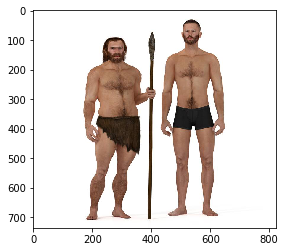

[output not shown]

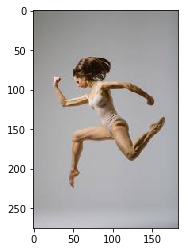

[output not shown]

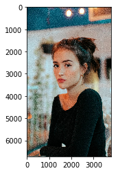

[output not shown]

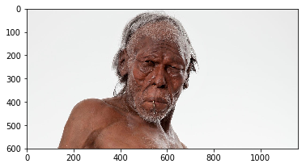

[output not shown]

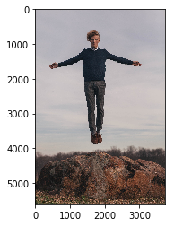

[output not shown]

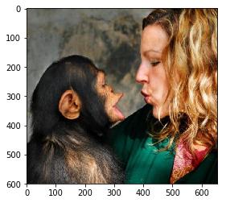

[output not shown]

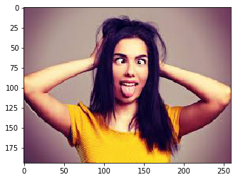

[output not shown]

```python
import os

for img_file in os.listdir('human_dir/'):
    img_path = os.path.join('human_dir', img_file)
    run_app(img_path)
    print(img_path)
    img = Image.open(img_path)
    plt.imshow(img)
    plt.show()

for img_file in os.listdir('dog_dir/'):
    img_path = os.path.join('dog_dir', img_file)
    run_app(img_path)
    print(img_path)
    img = Image.open(img_path)
    plt.imshow(img)
    plt.show()
```